## Exploratory Data Analysis of White Wines

## Ashutosh Singh

Looking at the names and values of data

```
##  [1] "X"                    "fixed.acidity"        "volatile.acidity"
##  [4] "citric.acid"          "residual.sugar"       "chlorides"
##  [7] "free.sulfur.dioxide"  "total.sulfur.dioxide" "density"
## [10] "pH"                   "sulphates"            "alcohol"
## [13] "quality"
```

```
## [1] 4898   13
```

```
## [1] 0
```

```
## 'data.frame':    4898 obs. of  13 variables:
##  $ X                   : int  1 2 3 4 5 6 7 8 9 10 ...
##  $ fixed.acidity       : num  7 6.3 8.1 7.2 7.2 8.1 6.2 7 6.3 8.1 ...
##  $ volatile.acidity    : num  0.27 0.3 0.28 0.23 0.23 0.28 0.32 0.27 0.3 0.22 ...
##  $ citric.acid         : num  0.36 0.34 0.4 0.32 0.32 0.4 0.16 0.36 0.34 0.43 ...
##  $ residual.sugar      : num  20.7 1.6 6.9 8.5 8.5 6.9 7 20.7 1.6 1.5 ...
##  $ chlorides           : num  0.045 0.049 0.05 0.058 0.058 0.05 0.045 0.045 0.049 0.044 ...
##  $ free.sulfur.dioxide : num  45 14 30 47 47 30 30 45 14 28 ...
##  $ total.sulfur.dioxide: num  170 132 97 186 186 97 136 170 132 129 ...
##  $ density             : num  1.001 0.994 0.995 0.996 0.996 ...
##  $ pH                  : num  3 3.3 3.26 3.19 3.19 3.26 3.18 3 3.3 3.22 ...
##  $ sulphates           : num  0.45 0.49 0.44 0.4 0.4 0.44 0.47 0.45 0.49 0.45 ...
##  $ alcohol             : num  8.8 9.5 10.1 9.9 9.9 10.1 9.6 8.8 9.5 11 ...
##  $ quality             : int  6 6 6 6 6 6 6 6 6 6 ...
```

Only the quality column which tells about the average quality of Wines can be used a categorical column in first pass. Others look like continuous values. Let’s see each of them one by one.

# Univariate Plots Section

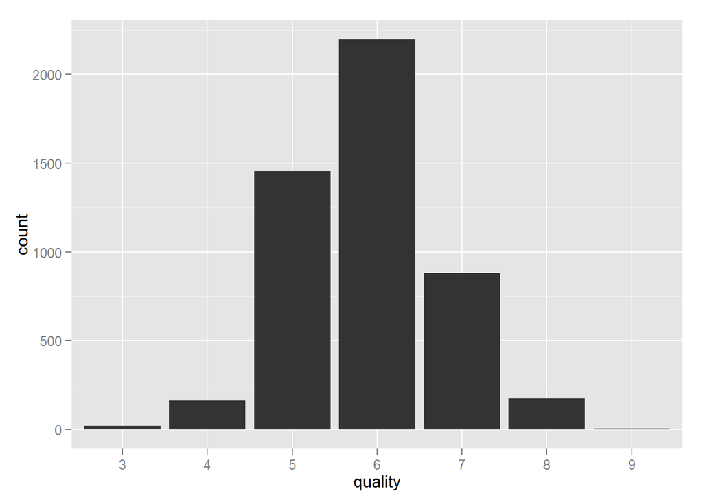

```
##    3    4    5    6    7    8    9
##   20  163 1457 2198  880  175    5
```

Most the wines are of average quality. So we have few data points to delve into qualities.

Lets take a look at other features.

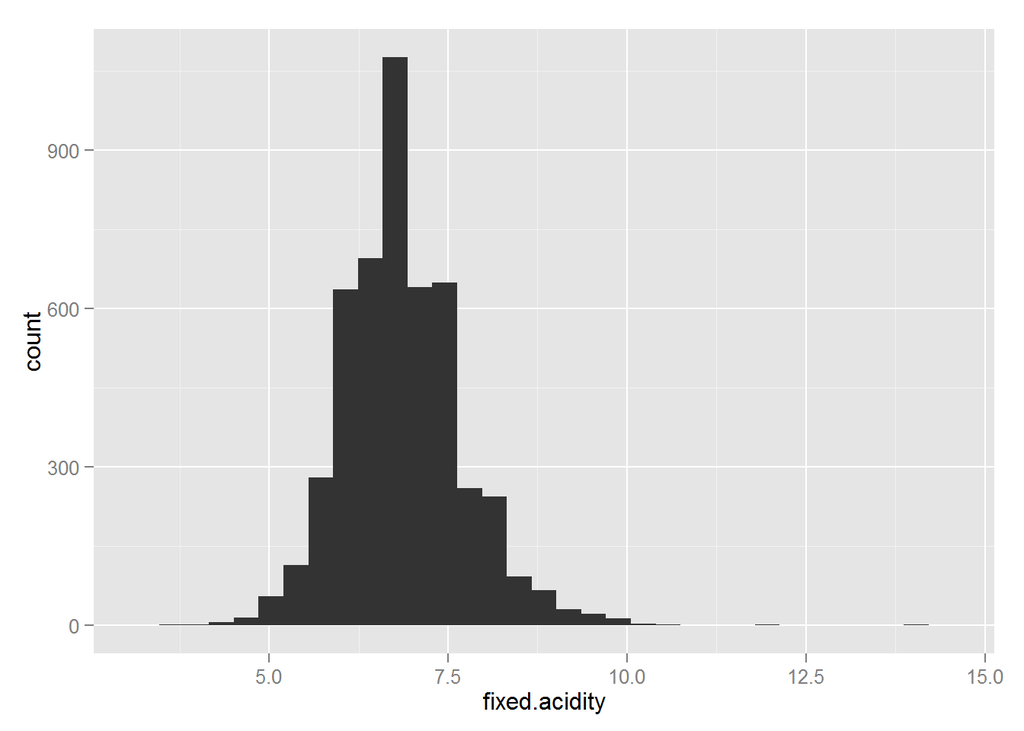

```
##    Min. 1st Qu.  Median    Mean 3rd Qu.    Max.
##   3.800   6.300   6.800   6.855   7.300  14.200
```

Above is the plot for fixed acidity (tartaric acid) which do not evaporate easily. The histogram gives a normal distribution with a clear peak in the middle.

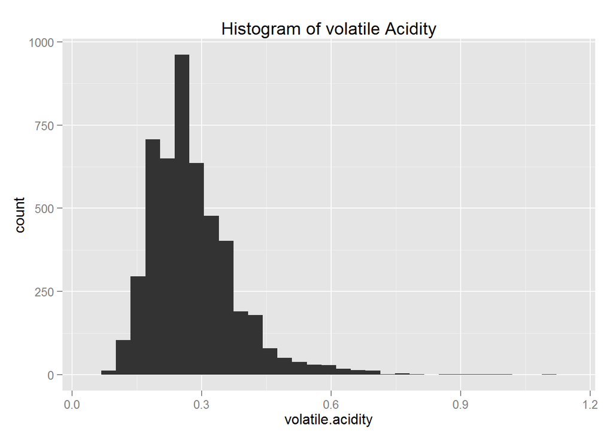

```
##    Min. 1st Qu.  Median    Mean 3rd Qu.    Max.
##  0.0800  0.2100  0.2600  0.2782  0.3200  1.1000
```

Above histogram of volatile acidity, the amount of acetic acid in wine, which at too high of levels can lead to an unpleasant, vinegar taste

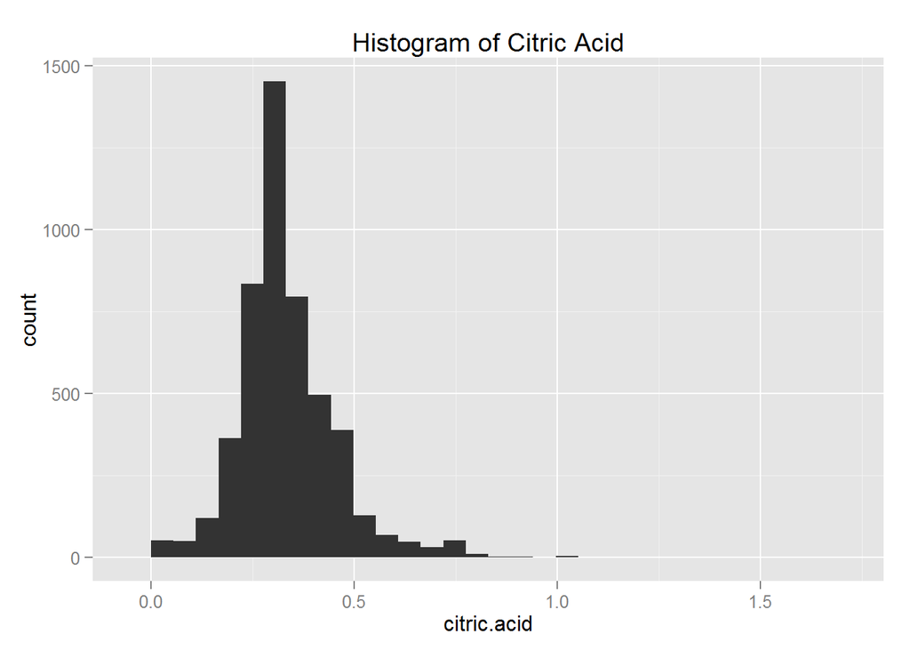

```
##    Min. 1st Qu.  Median    Mean 3rd Qu.    Max.
##  0.0000  0.2700  0.3200  0.3342  0.3900  1.6600
```

Citric Acid , found in small quantities, citric acid can add ‘freshness’ and flavor to wines.

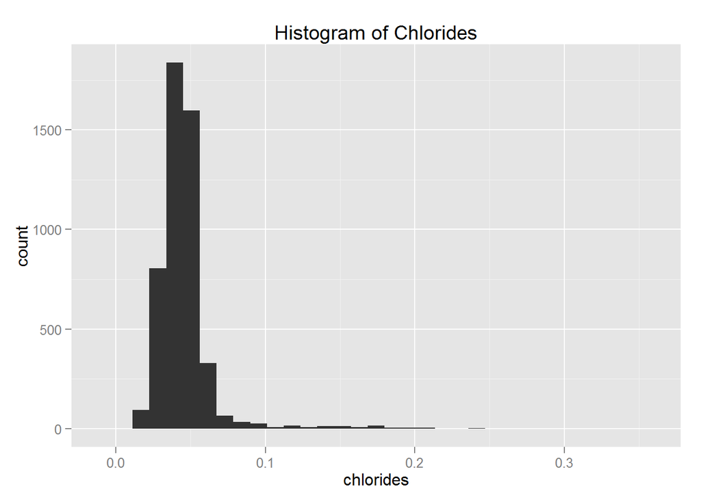

```
##    Min. 1st Qu.  Median    Mean 3rd Qu.    Max.
## 0.00900 0.03600 0.04300 0.04577 0.05000 0.34600
```

Chlorides represents the amount of salt in the wine. The plot looks skewed as most of the values are concentrated on the left side.

```
##    Min. 1st Qu.  Median    Mean 3rd Qu.    Max.
##     9.0   108.0   134.0   138.4   167.0   440.0
```

```
##    Min. 1st Qu.  Median    Mean 3rd Qu.    Max.
##    2.00   23.00   34.00   35.31   46.00  289.00
```

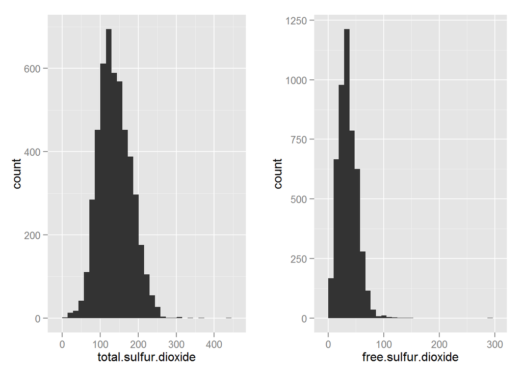

The above histograms show the free sulfur dioxide and total sulfur dioxide These prevent the microbial growth and oxidation of wine after it is packed.

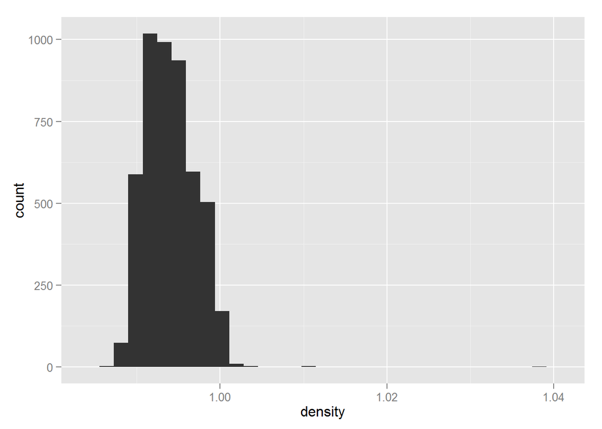

```
##    Min. 1st Qu.  Median    Mean 3rd Qu.    Max.
##  0.9871  0.9917  0.9937  0.9940  0.9961  1.0390
```

The plot is almost normal and density represents the density of water. It depends on alcohol content and sugar content. This needs to be looked at.

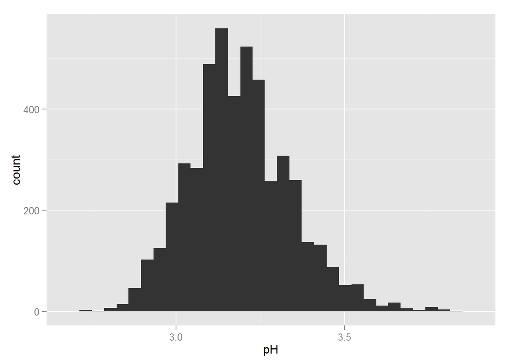

```
##    Min. 1st Qu.  Median    Mean 3rd Qu.    Max.
##   2.720   3.090   3.180   3.188   3.280   3.820
```

The pH value describes the acidity or the basicity of wine on a scale of 1-14. Most of the wines have values in 3-4 range as indicated in histogram.

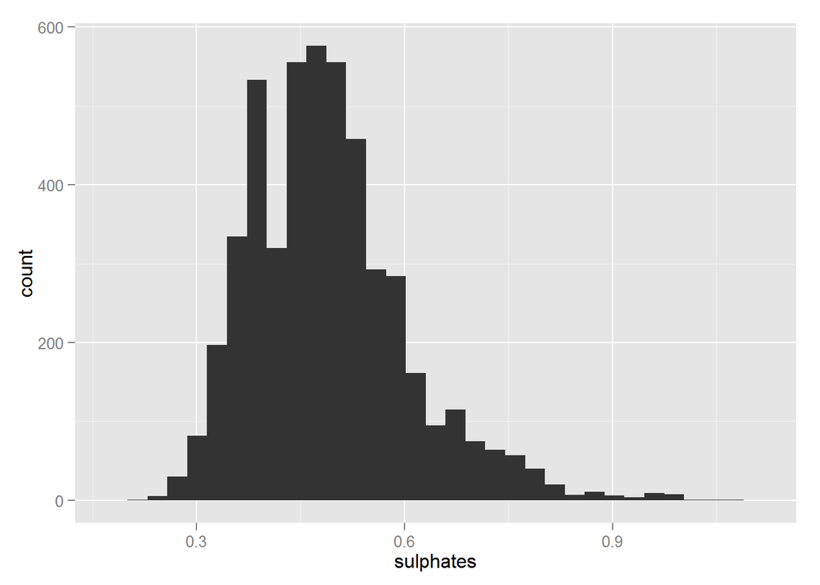

```
##    Min. 1st Qu.  Median    Mean 3rd Qu.    Max.
##  0.2200  0.4100  0.4700  0.4898  0.5500  1.0800
```

The sulphates are an additive to wine to stop the microbial growth.

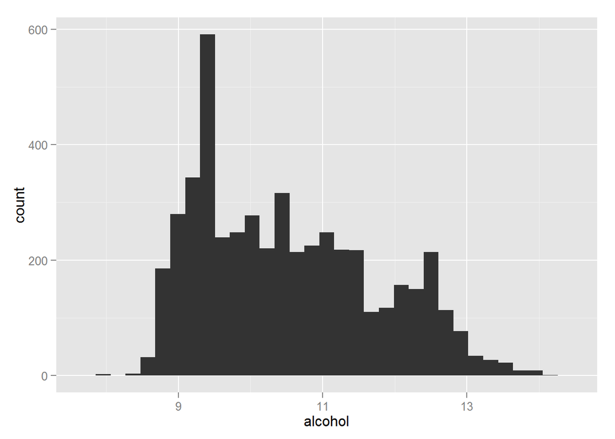

```
##    Min. 1st Qu.  Median    Mean 3rd Qu.    Max.
##    8.00    9.50   10.40   10.51   11.40   14.20
```

Alcohol represents the alcohol content of the wine in % by volume.

To a layman, a wine looks like just alcohol and water but looking at these physiochemical properties I get the idea that there is more to a wine than just alcohol. Now we dive deep into them.

The residual sugar histogram is skewed so plotting it in log transformation we get

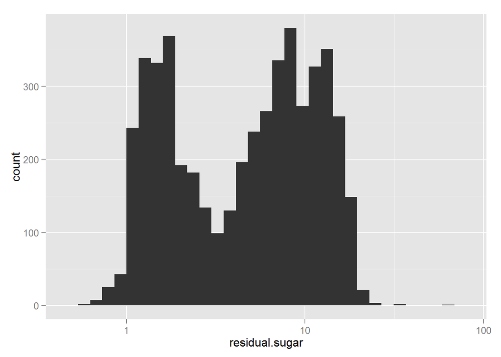

There exists a bimodal distribution. Residual sugar is what is left when the fragmentation stops.

# Univariate Analysis

### What is the structure of your dataset?

The data contains 4898 observations of white wine and their physiochemical analysis as features. A total of 11 features are used and the quality variable is used as output which also serves as a categorical variable.

All features except quality are continuous.The quality feature domain is from 0 to 10 but the range is available from 3 to 9. The quality of wine is subjective so average was used to depict quality by atleast 3 observers.

### What is/are the main feature(s) of interest in your dataset?

The quality feature rises to the top . Also since I have never tasted wine and as an engineer I thought of predicting the quality of wine by its features. Residual sugar also seems interesting as this what makes wines taste sweeter. Also content of residual sugar is maintained and the sulphides are added to preserve the sugar content from further fermentation.

Last I think most important is alcohol for obvious reasons.

### What other features in the dataset do you think will help support your

investigation into your feature(s) of interest?

I think pH value and density features should be explored more in association with the quality of wines

### Did you create any new variables from existing variables in the dataset?

### Of the features you investigated, were there any unusual distributions?

Did you perform any operations on the data to tidy, adjust, or change the form of the data? If so, why did you do this? I investigated the residual sugar feature since the data looks skewed in the first pass. I applied the log transformation on it which clearly shows a bimodal relationship between the wines and the sugar after fermentation. The plot shows that mostly the sugar is determined by keeping it low or high.

# Bivariate Plots Section

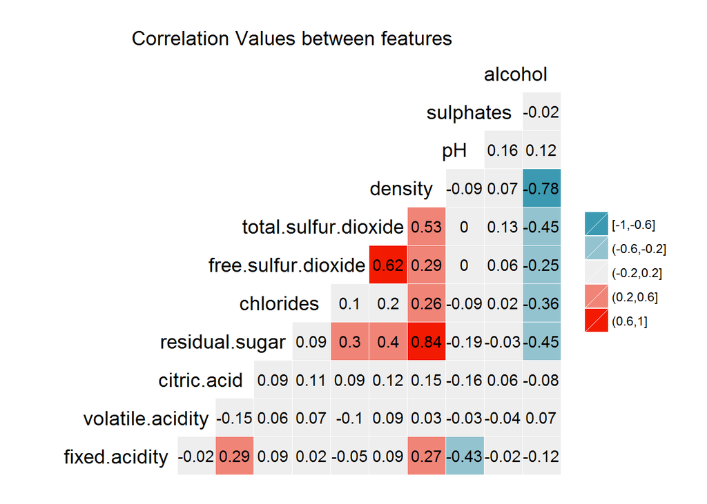

For a quick overview of the data I plotted a scatterplot matrix of the variables to look at the correlation and the distribution with other variables.

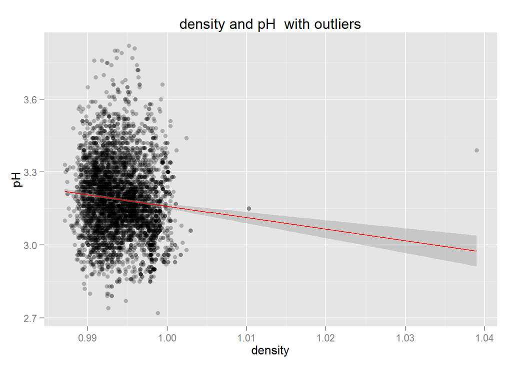

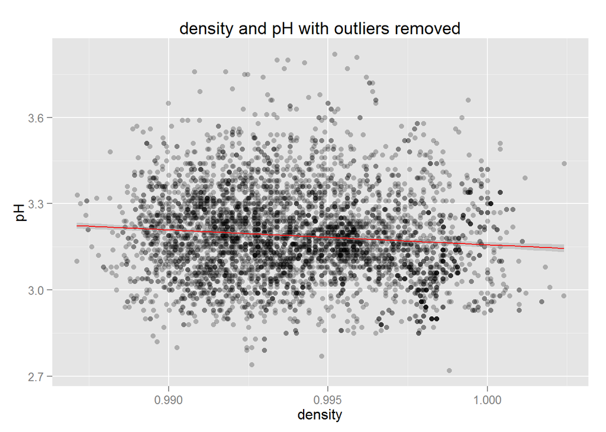

From the above pairs matrix a relationship between density and residual sugar looks linear. The correlation between them is **0.83** Plotting them again

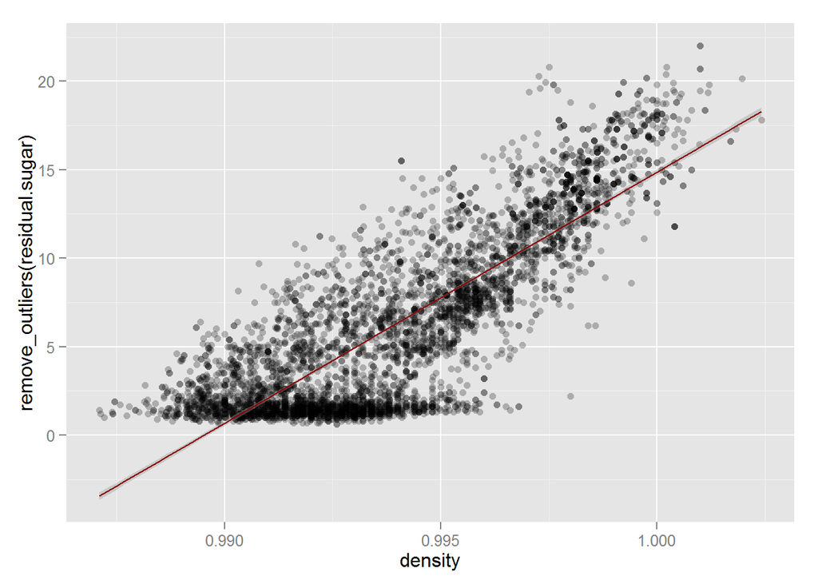

Since our categorical value and also output is only quality. Lets take a look at how the values of different features relate with quality.

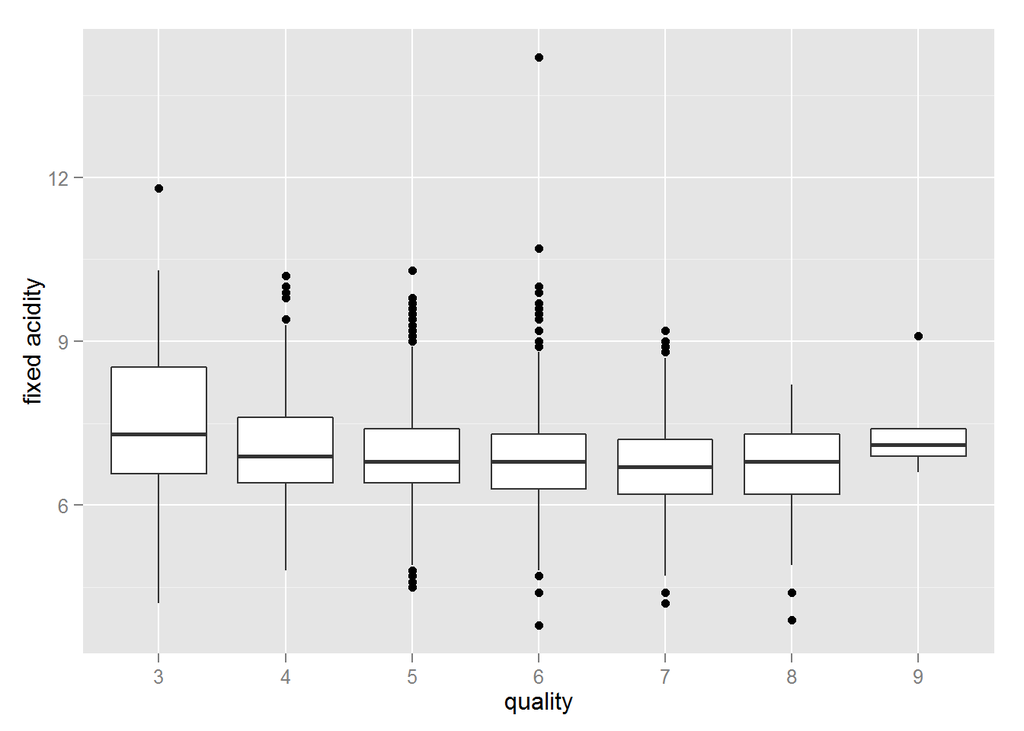

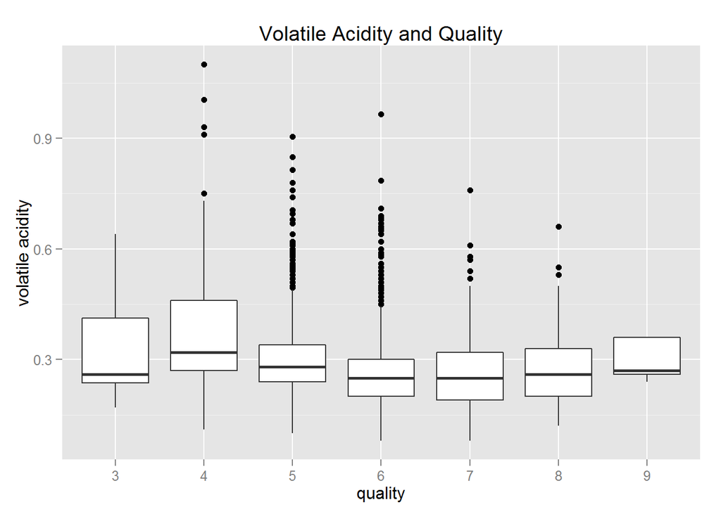

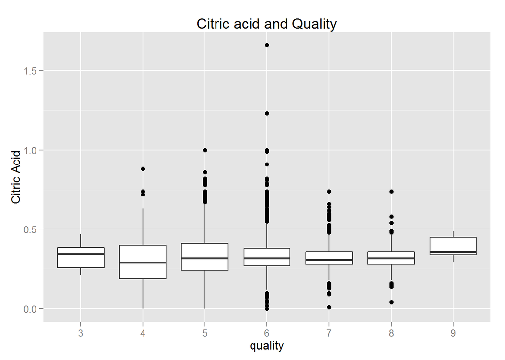

Looking at the relationship between residual sugar and qaulity

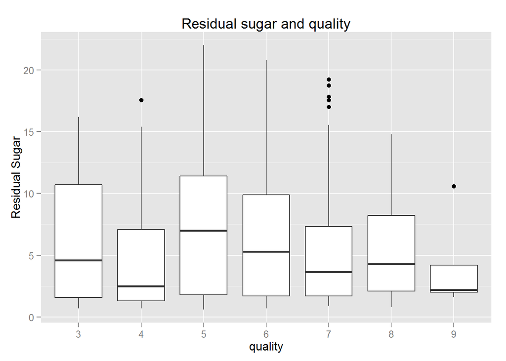

It looks like low residual sugar and wine quality are correlated but we also get almose same values of residual sugar for wines rated poor. It is inconclusive to use residual sugar for discriminating wines.The median value is low than others

Moving on to quality and chlorides

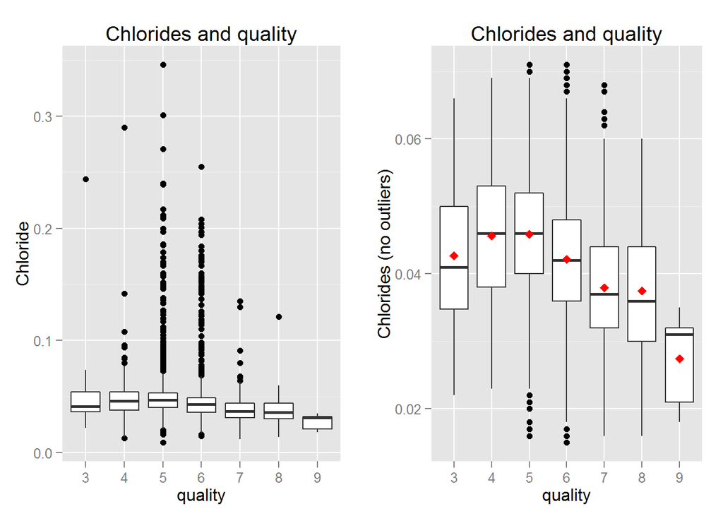

I have removed the outliers from the chlorides data as they were skewing the plot and we may be missing the big picture.The red point shows the mean values. From the box plot it is clear that high quality wines have low chlorides. We will explore this aspect in detail later on.

The next feature is Free sulfur dioxide. Since *free sulfur dioxide* and *total sulfur dioxide* are correlated with almost linear relationship,looking at them show similar plots

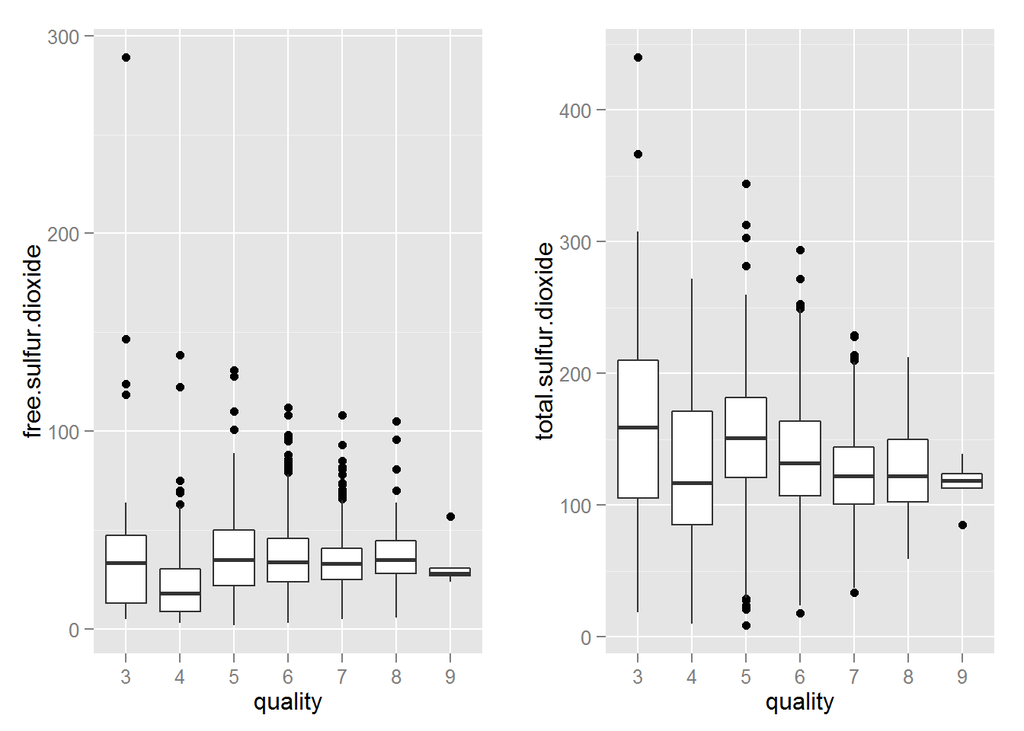

The plot looks almost same except for scale which is obvious and there is also strong correlation between them as shown in plot below.

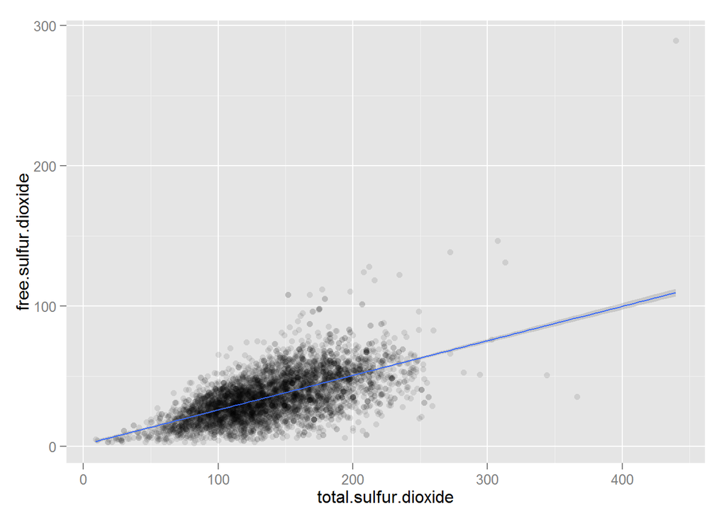

Now looking at quality with pH, there is a meek indication of high pH as compared to othes for high quality wines.

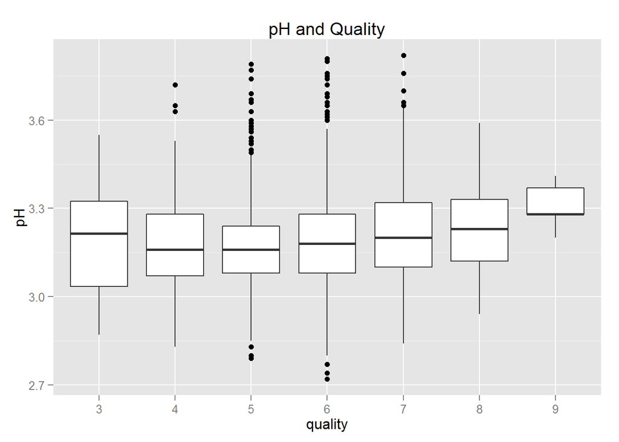

But no such patter emerges when we compare sulphates with the quality.

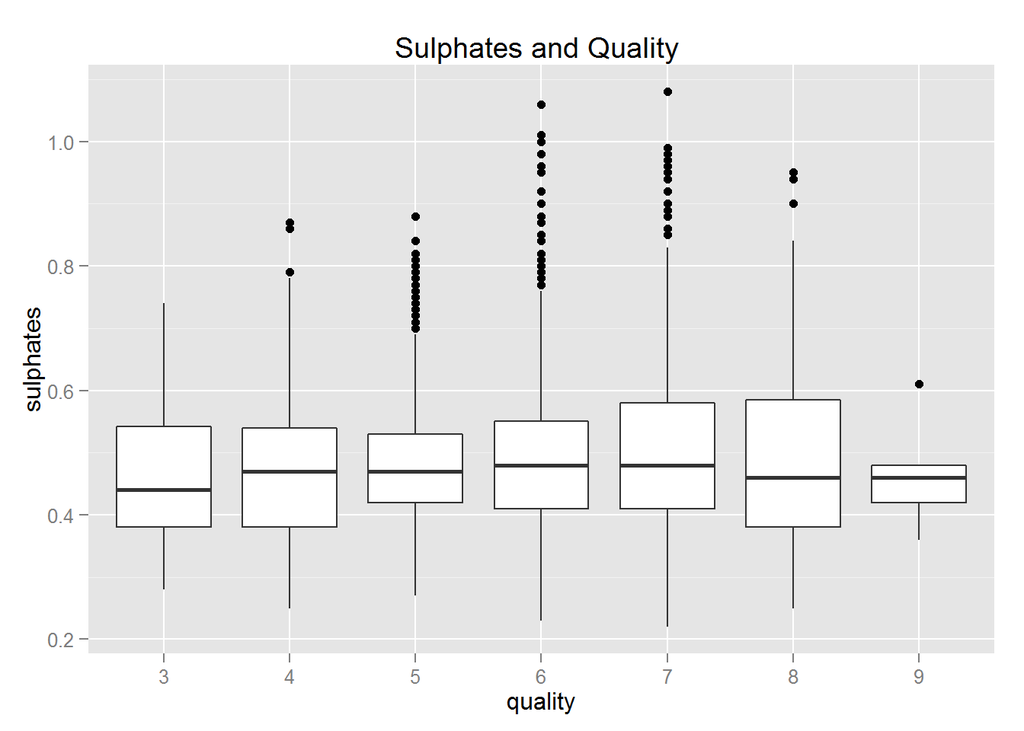

Finally we have alcohol with quality.

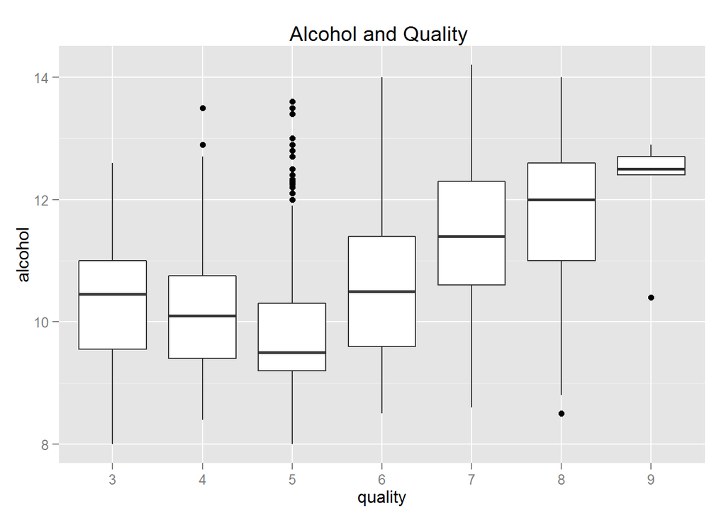

These box plots above give us an average idea of what features change according to quality. Some specific mentions are

- chlorides have low quantity with high quality
- density is also low for high quality wines
- alcohol is high for high quality wines

These comparisons give us a bird-eye view of how individual features impact the quality of the wines. Now lets take an overview of how these features affect each other.

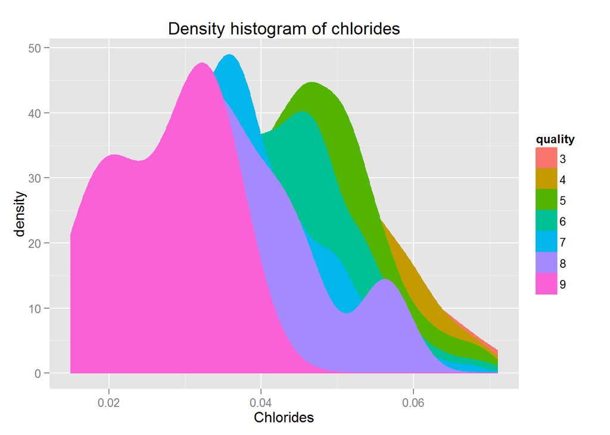

We get a clear picture that high quality rated wines have less chlorides.But the correlation is not straight. Low quality rated wines (quality 3) also have less chlorides than the average. There may be other factors.

Taking another look at density feature and quality

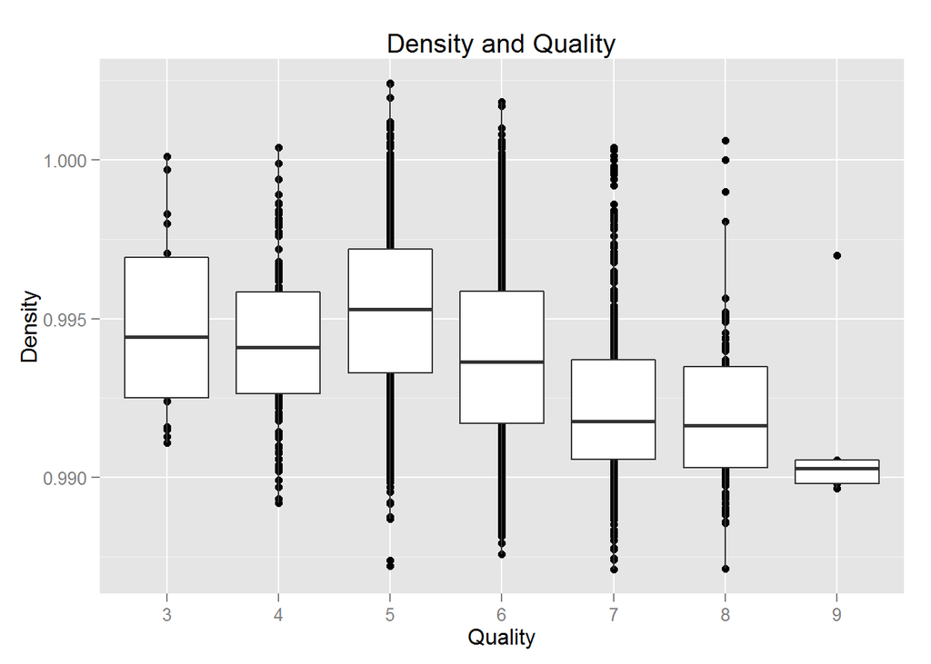

```
##
##    3    4    5    6    7    8    9
##   20  163 1457 2198  880  175    5
```

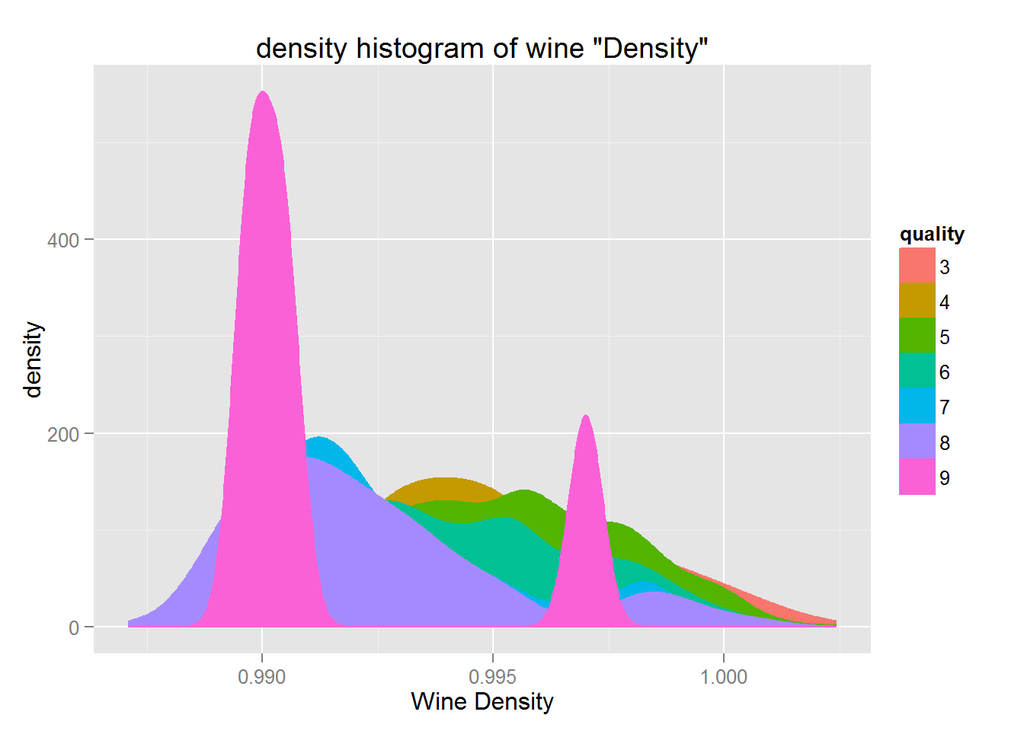

From the plot and the values we have less data for high quality rate wines : only 1060 but it is evident that high-rated wines have less density than the low rated wines.

And now taking a look at the boxplot of alcohol and quality

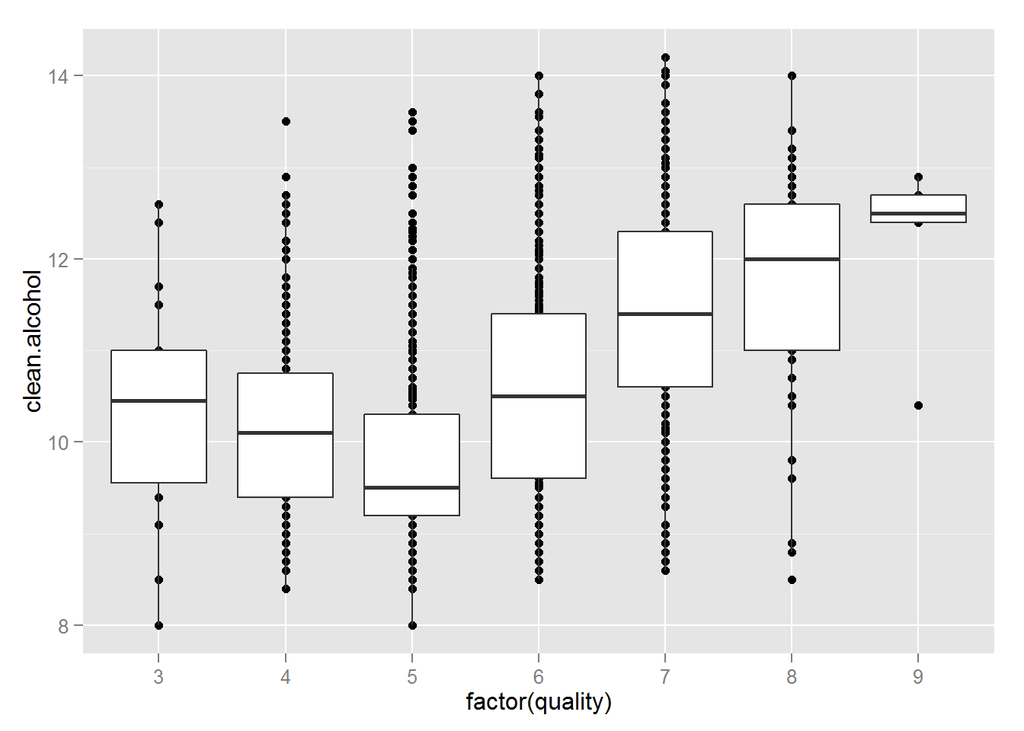

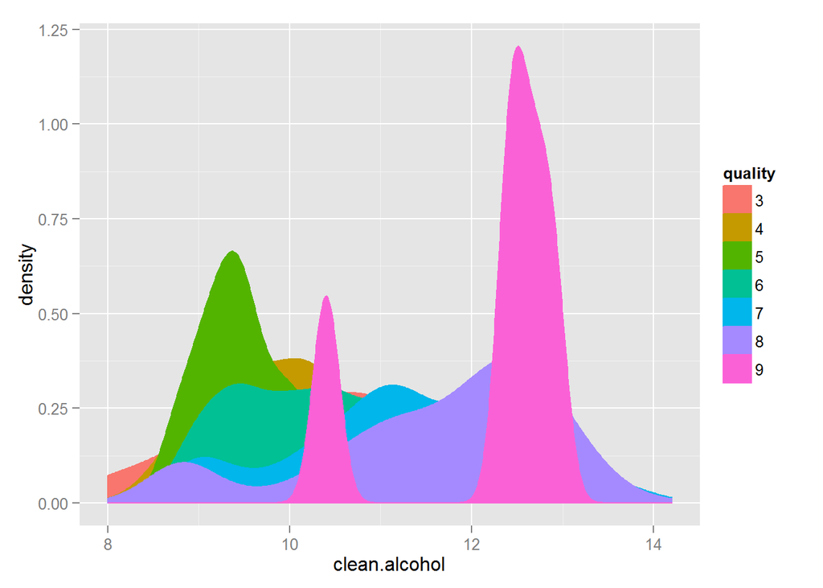

The intuition was right the alcohol content of the high-rated wines is greater than in low-rated wines.